# Analysis of COVID19 Data

Yasushi Yamanaka

2023-06-23

### Data Source

This data is provided by the Center for Systems Science and Engineering (CSSE) at Johns Hopkins University. It originates from https://github.com/CSSEGISandData/COVID-19. It contains US and global COVID19 related data.

### Project Objective

- Analyze US and global cumulative and incremental cases
- Analyze US and global cumulative deaths
- Build predictive model of global cumulative cases
- Identify possible biases of the data

### Step 1 Importing CSV File

```r
library(tidyverse)
library(forecast)
library(astsa)
files <- c("time_series_covid19_confirmed_US.csv", "time_series_covid19_confirmed_global.csv", "time_series_covid19_deaths_US.csv", "time_series_covid19_deaths_global.csv")

global_cases <- read_csv(files[2])
global_deaths <- read_csv(files[4])
us_cases <- read_csv(files[1])
us_deaths <- read_csv(files[3])
```

### Step 2 Tidying Data

1. Pivot table columns to rows (**date** and **cases**/**deaths**)

```r
global_cases <- global_cases %>% pivot_longer(cols=-c("Province/State", "Country/Region", "Lat", "Long"), names_to="date", values_to="cases")
global_deaths <- global_deaths %>% pivot_longer(cols=-c("Province/State", "Country/Region", "Lat", "Long"), names_to="date", values_to="deaths")

us_cases <- us_cases %>% pivot_longer(cols=-(UID:Combined_Key), names_to="date", values_to="cases")
us_deaths <- us_deaths %>% pivot_longer(cols=-(UID:Population), names_to="date", values_to="deaths")
```

2. Drop unnecessary columns: **Lat**, **Long** of **global_cases** and **global_deaths**
3. Unify joined column names: **Province/State** -> **Province_State** and **Country/Region** -> **Country_Region**
4. Change **date** into date format.
5. Remove unnecessary columns: **UID**, **iso2**, **iso3**, **code3**, **FIPS**, **Lat**, **Long_** of **us_cases**, **us_deaths**

```r
global_deaths <- global_deaths %>% select(cols=-c("Lat", "Long")) %>% rename(Province_State="Province/State", Country_Region="Country/Region") %>% mutate(date=mdy(date))
global_cases <- global_cases %>% select(cols=-c("Lat", "Long")) %>% rename(Province_State="Province/State", Country_Region="Country/Region") %>% mutate(date=mdy(date))

us_cases <- us_cases %>% select(Admin2:cases) %>% mutate(date=mdy(date)) %>% select(cols=-c("Lat", "Long_"))
us_deaths <- us_deaths %>% select(Admin2:deaths) %>% select(cols=-c("Lat", "Long_")) %>% mutate(date=mdy(date))
```

6. Merge **global_cases** and **global_deaths** to **global** by joining common columns
7. Merge **us_cases** and **us_deaths** to **us** by joining common columns

```r
global <- full_join(global_cases, global_deaths)
us <- full_join(us_cases, us_deaths)
```

### Step 3 Data Analysis

1. Prepare data for analysis

```r
global_totals <- global %>% group_by(date) %>%
                 summarise(cases=sum(cases), deaths= sum(deaths)) %>%
                 ungroup()
us_totals <- us %>% group_by(Country_Region, date) %>%
             summarise(cases=sum(cases), deaths=sum(deaths)) %>%
             ungroup()

global_totals <- global_totals %>% mutate(fatality=deaths/cases, incre_cases=c(0, diff(cases)))
us_totals <- us_totals %>% mutate(fatality=deaths/cases, incre_cases=c(0, diff(cases)))
```

2. Plot total global and US cases per day. We can observe three phases in both curve. First, from 2020 to 2021, when ALPHA was the main variant, cases grew steadily all over the world. Second, when DELTA became the main variant from 2021 to 2022, we can see steep increase in cases. Third, finally OMICRON befell and accompanied with yet another sharp increase of cases. In addition, leveling of new cases can be observed both in global and US beginning from 2023.

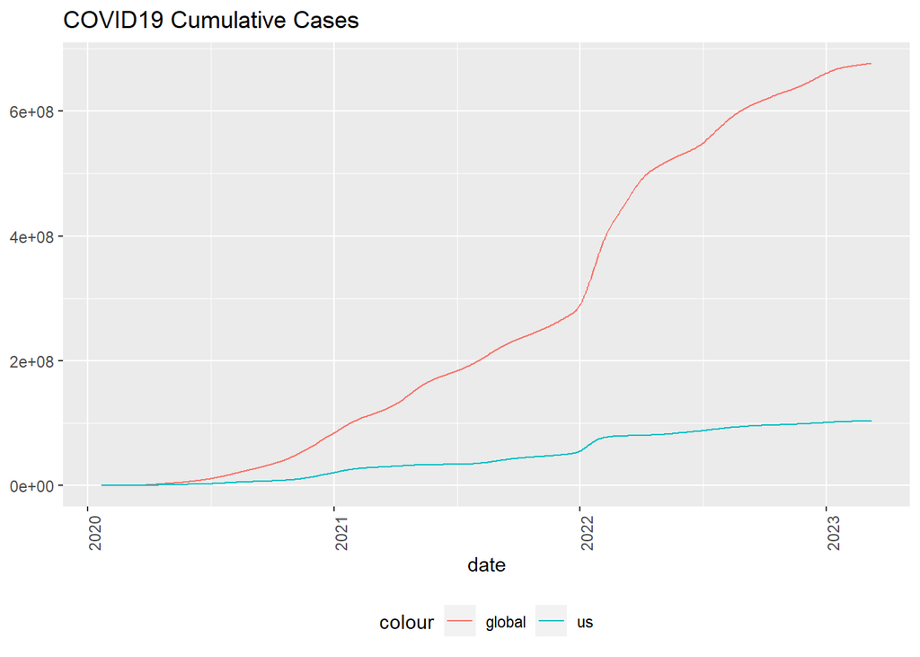

```r
ggplot(global_totals, aes(x=date, y=cases)) + geom_line(aes(color="global")) +
  geom_line(data=us_totals, aes(y=cases, color="us")) +
  theme(legend.position="bottom", axis.text.x=element_text(angle=90)) +
  labs(title="COVID19 Cumulative Cases", y=NULL)
```

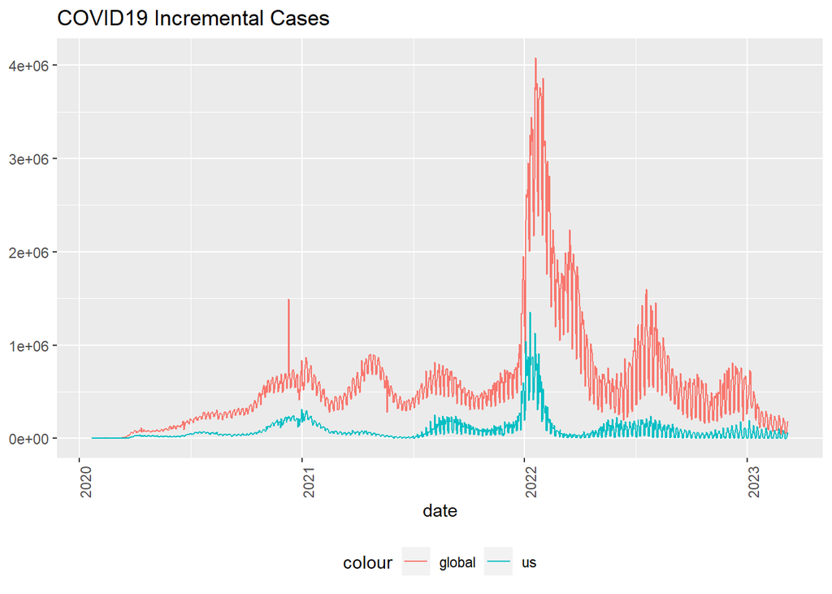

```r
ggplot(global_totals, aes(x=date, y=incre_cases)) + geom_line(aes(color="global")) +
  geom_line(data=us_totals, aes(y=incre_cases, color="us")) +
  theme(legend.position="bottom", axis.text.x=element_text(angle=90)) +
  labs(title="COVID19 Incremental Cases", y=NULL)
```

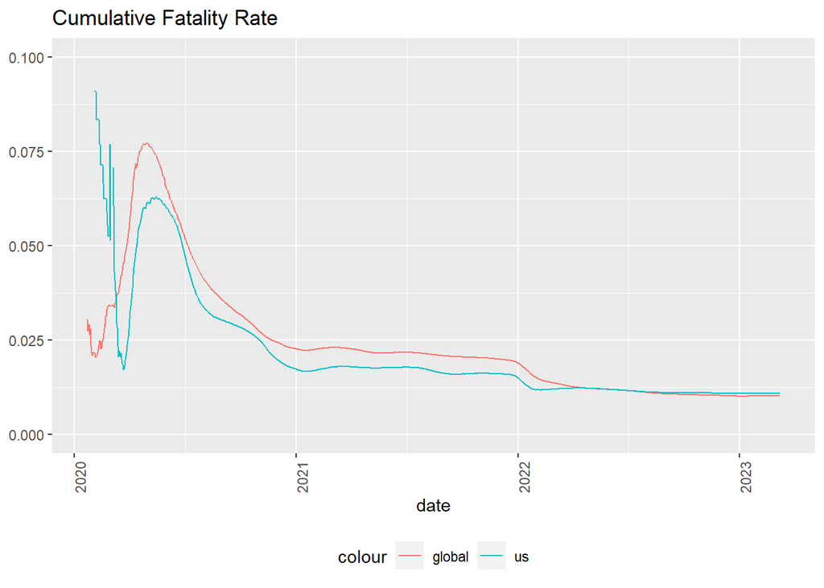

```r
ggplot(global_totals, aes(x=date, y=fatality)) + geom_line(aes(color="global")) +
  geom_line(data=us_totals, aes(y=fatality, color="us")) +
  theme(legend.position="bottom", axis.text.x=element_text(angle=90)) +
  labs(title="Cumulative Fatality Rate", y=NULL) + ylim(0, 0.1)
```

### Step 4 Building Model

We apply SARIMA model to predict the global cumulative cases. Training data set is from 2020/1/22 to 2022/12/31, test data set is from 2023/1/1 to 2023/3/9. We can observe that the predictive model doesn’t capture the leveling trend well. It is because simple model such as SARIMA only make prediction based on historical data. In complex phenomenon like COVID19 transmission, we need much more sophisticated model to get the job done.

```r
ts <- ts(global_totals$cases, start=c(2020, 22), frequency=365)
train <- window(ts, start = c(2020,22), end = c(2022,365))
test <- window(ts, start=c(2023,1))

sarima.forecast <- sarima.for(train, n.ahead=length(test), p=1,d=1,q=1,P=1,D=1,Q=0,S=12)
```

[figure not shown]

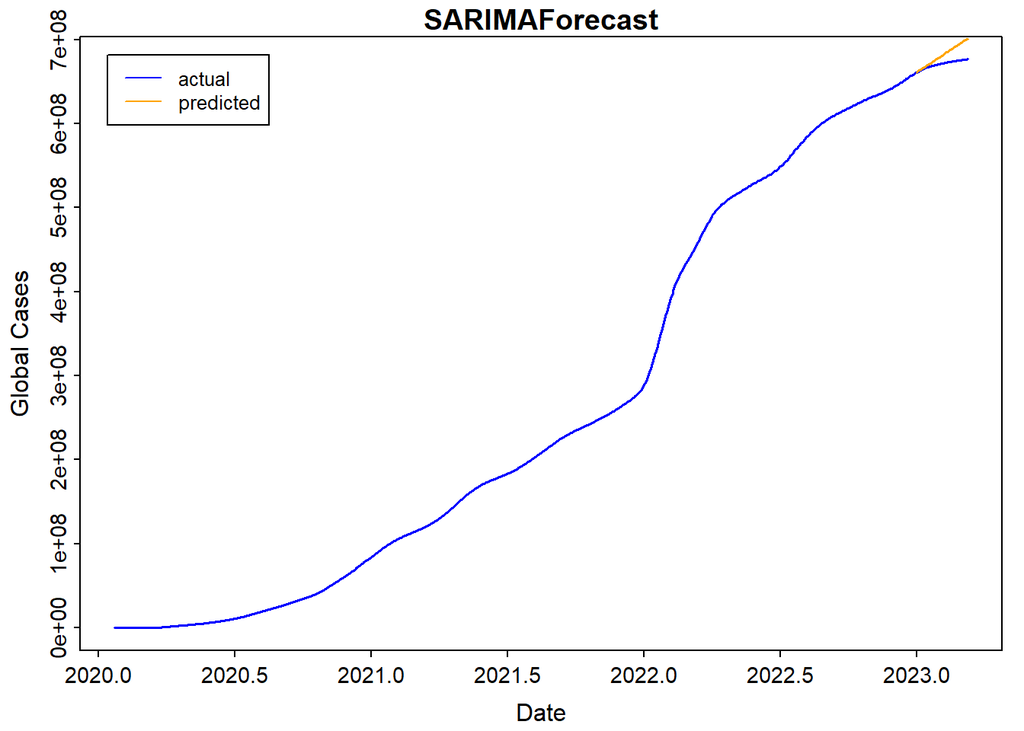

```r
plot(ts,col="blue",xlab="Date", ylab="Global Cases",main="SARIMAForecast", type='l',lwd=1.5)
lines(sarima.forecast$pred,col="orange",lwd=1.5)
legend("topleft",inset=.03,legend=c("actual", "predicted"),col=c("blue","orange"),lty=1:1,cex=0.8)
```

### Step 5 Conclusion

- According to COVID19 cases, we can observe three phases in the US and global data. Two rapid increasing stages appear in 2021 to 2022 and 2022 to 2023 when DELTA and OMICRON were the mainstream variants.
- As COVID19 variants become more transmissive, they are also less fatal. We can confirm this trend from US and global cumulative fatality rates.
- Simple time series model such as SARIMA cannot predict problem of COVID19 transmission well. More complex models are needed to get acceptable results.
- Biases that can affect COVID19 data: The availability and accessibility of testing can vary across different regions or populations. This can lead to under-reporting of cases in areas with limited testing capacity, which may result in an incomplete and skewed representation of the true number of COVID-19 cases. In addition, there can be inconsistencies in how cases and deaths are reported across different jurisdictions or countries. Variations in reporting standards, criteria for counting COVID19 cases, and data collection methods can lead to discrepancies and make it difficult to compare data accurately.